# 2024 Seward Park Hemlock Study

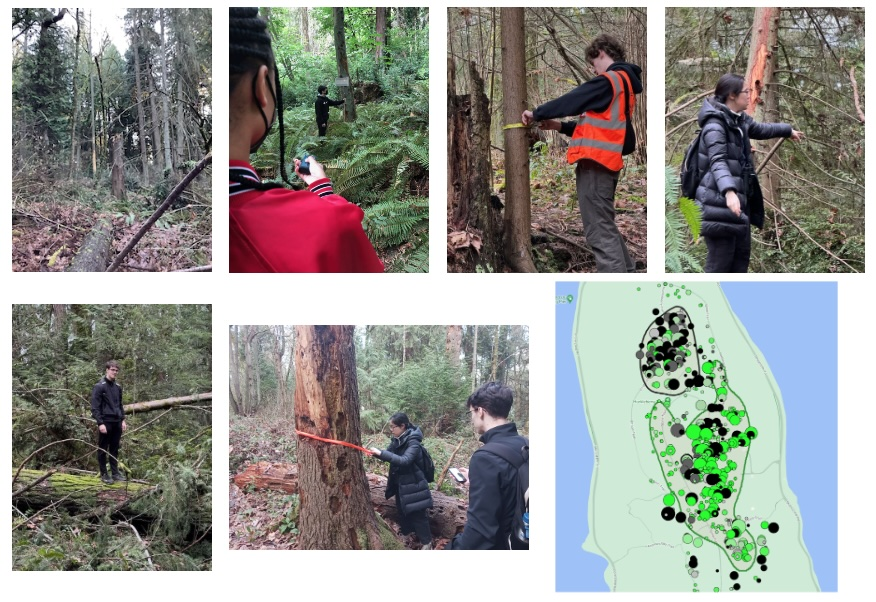

The venerable Western Hemlock - Washington’s state tree - has been in decline in the Puget Lowlands since at least 2015. These trees are dying - not everywhere all at once - but intermittently, often in clusters throughout low elevations west of the Cascades. This is a departure from normal hemlock population dynamics and from the intermittent effects of endemic fungal diseases.

By 2017, researchers were attributing the mortality to *Rhizoctonia butini*, a fungus in the order Cantharellales. But this hypothesis has since been abandoned (according to personal communications from Jared LeBoldus, OSU Corvallis, and Kevin Zobrist, WSU). No new explanation has emerged, but we often hear the suggestion that the mortality is due to normal old age or climate change.

For a decade and more, we have watched an accelerating decline of Western Hemlock in Seward Park’s 120-acre old-growth urban forest. We see many dead trees, both young and old, most of them concentrated in six acres in a northern portion of the forest. This dead zone continues to grow.

Yet we also see many healthy hemlocks. We see trees of all ages, from young saplings to 250 year old giants. We see only intermittent normal mortality.

Here, we establish that neither climate nor normal senesence is killing the hemlocks. We establish the need for further research to figure out the mechanisms of mortality - for the benefit of Seward’s old-growth forest, and for forests throughout the region.

We further propose that Seward’s forest provides **an ideal site for a [natural experiment](https://en.wikipedia.org/wiki/Natural_experiment)**, an excellent opportunity for deeper research into the mechanisms of Puget Lowland Western Hemlock decline. We identify two dramatically different populations of hemlock at Seward. Their are no obvious differences in the site and age characteristics of the two populations. Careful study is needed to identify the hidden factors responsible for these very different outcomes, for two essentially identical populations of trees.

### Mapping and Measuring at Seward Park

Between January and March 2024, two Univeristy of Washington students from the Program on the Environment in their senior Capstone Research Project, along with a Garfield High School junior, and Seward’s Green Seattle Partnership forest steward, guided by Dr. Tim Billo of the UW, spent nine weeks in the forest collecting data to test our hypothesis. The study participants are listed in Appendix A, below.

We also used data collected in the summer of 2021 by CHOOSE 180 interns.

### Our Results

[figure not shown]

*Green dots are healthy trees, black and gray dots are dead or diseased trees, and dot diameter indicates tree diameter. The shaded regions indicate concentrations of healthy (green border) and affected trees (black border). An interactive version of the above map, along with the full dataset, is available [here](https://pshannon.net/hemlockSurvey2024).*

This mapping, and subsequent density calculations establish, with statistical rigor, that though healthy and failing trees are found throughout the forest, there are two distinct populations of Western Hemlock in Seward’s Forest.  
Sick and dying trees are heavily concentrated in a contiguous region in the north of the forest. Healthy hemlocks are found south, centrally and east throughout the forest. And as we will now show, the dramatic die-off is not the simple consequence of climate change or normal senescence.

### The Climate Change Claim

This is easily dispensed with. Or, at least, reduced to a minor role. The two regions *may* have significant micro-climate differences, or micro-site characteristics which contribute to differential mortality. But it is unlikely that any decade-scale climate change phenomena, showing up as significant differences in micro-scale weather patterns, will explain the radical mortality difference of the two regions, graveyard and garden.

### The Natural Senescence Claim

Here we show that big old trees are roughly equally represented in the two regions, but that the health of those trees is dramatically different. (See Appendix B, below, explaining omission of younger trees, and presenting statistical tests.)

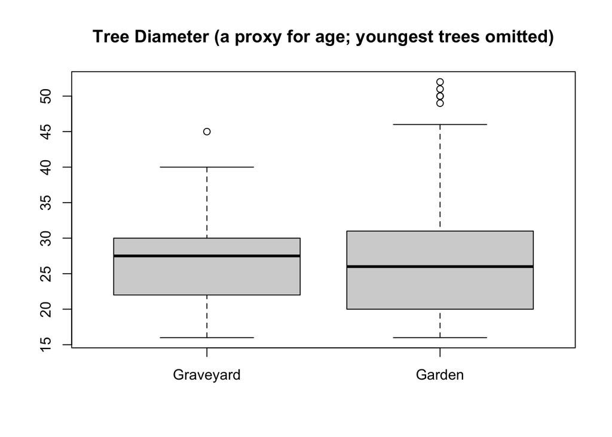

*The two gray boxes indicate that most of the trees at both sites have the same 20-30 inch diameter, and that the very largest trees are found, as you might expect, in the healthy (garden) region. The black lines in the gray boxes indicate the median diameter in each region.*

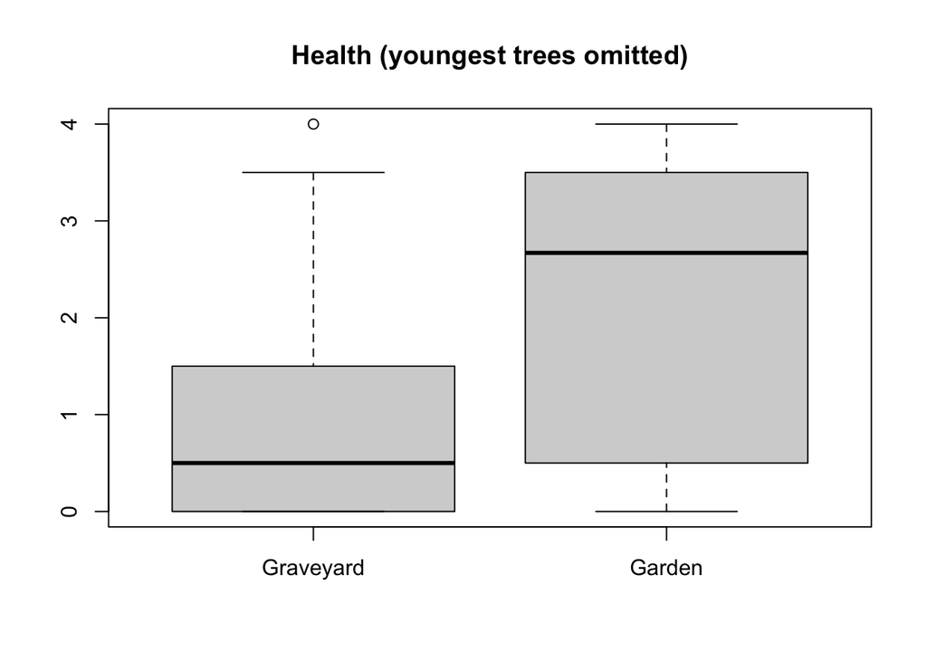

*Here we see that the graveyard hemlocks are mostly dead or in poor health, that the garden hemlocks are by and large healthy, though with some diseased and dead trees - as you would expect to find in any healthy forest. Calculation of statistical significance for this contrast is presented in Appendix D.*

#### Conclusion

Our nine-week community and student science study establishes that

1. Seward Park’s old-growth forest hemlock die-off is dramatic and concentrated in one (expanding) six acre region.
2. Is not caused simply by senescence or weather patterns,
3. It provides an opportunity for further (professional) study.

So what is going on? Is it fungi? Insects? Plant diseases? Some combination of these? It seems likely that multiple lines of research – such as DNA sequencing of leaves and the trees’ mycorrhizal fungi, entomological studies, and root rot analyses – may be needed to understand this problem.

We offer one caveat in closing. Our past visits to other affected sites suggested to us that Seward mortality, and regional mortality, are the same phenomenon. But in this study we did not collect observations at other sites. Therefore we have not yet established that Seward’s hemlock mortality, and that of the region, are identical. Detailed field observations are needed, perhaps laboratory and molecular methods as well.

### Appendix A: Participants

- Tim Billo, UW Faculty, College of the Environment
- Nate Butcher, Garfield High School junior
- Eric Holmquist, UW Program on the Environement, senior
- Paul Shannon, Green Seattle Partnership Forest Steward
- Muwei Zhang, UW Program on the Environement, senior

### Appendix B: Filtering Trees by Size Before Comparing Health

We motivate and justify this filtering here.

First, let us examime the relative ages of graveyard trees and garden trees.

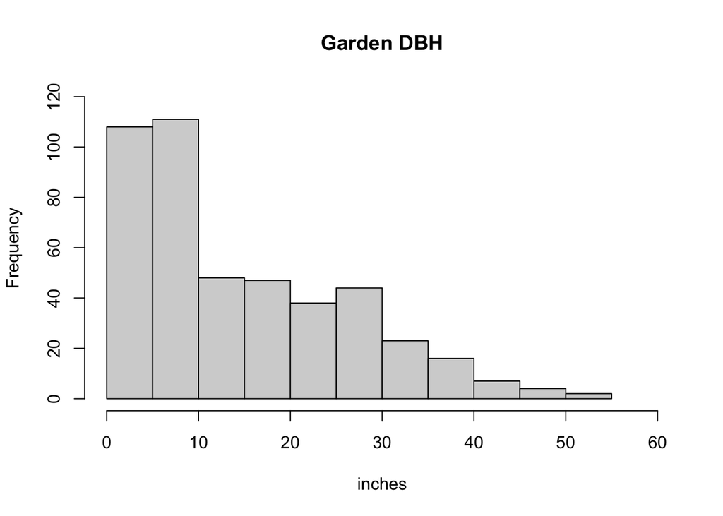

```r
hist(subset(tbl, loc=="garden")$dbh, main="Garden DBH", xlab="inches", xlim=c(0,60), ylim=c(0,120))
```

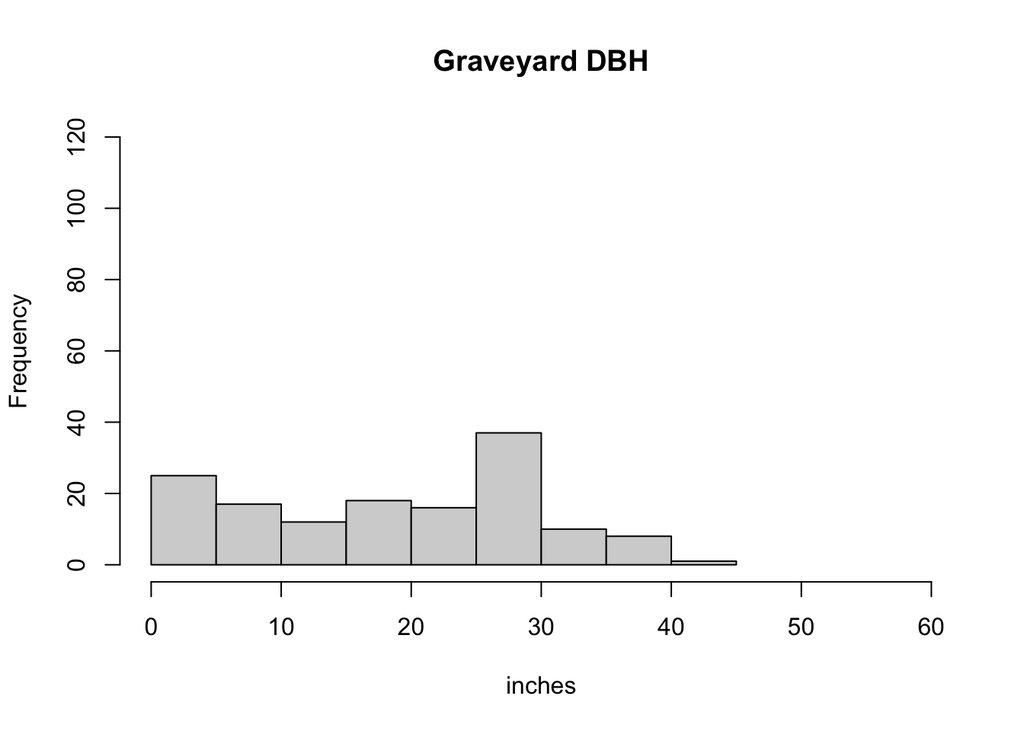

```r
hist(subset(tbl, loc=="graveyard")$dbh, main="Graveyard DBH", xlab="inches", xlim=c(0,60), ylim=c(0,120))
```

(Two explanations for the paucity of young trees in the graveyard occur to us; there may be others. First, that this region is no longer conducive to hemlock growth for trees of any age, including seedlings and saplings. Second, the heavy mortality of larger trees may have lead to diminished seed source in recent years.)

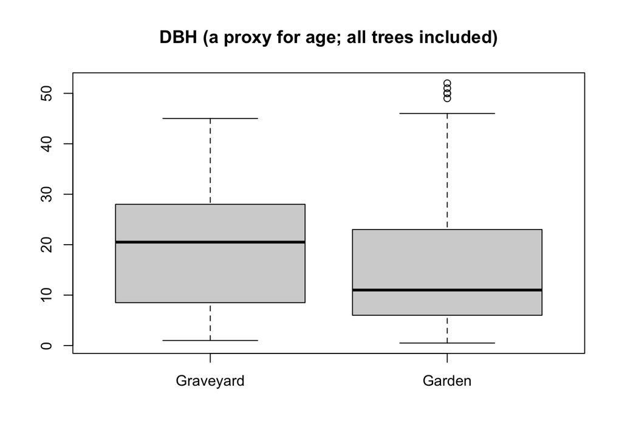

```r
boxplot(subset(tbl, loc=="graveyard")$dbh,
           subset(tbl, loc=="garden")$dbh,
        main="DBH (a proxy for age; all trees included)",
        names=c("Graveyard", "Garden"))
```

In this view, the distribution of trees in the graveyard - all trees - is somewhat larger.

However, this boxplot does not answer the question we are actually asking in this study: are hemlocks dying due to old age? We can best answer this by comparing the health of large trees in the two populations: apples to apples, big (old) trees to big (old) trees.

We can see that the distribution of older trees is roughly similar in the two groups:

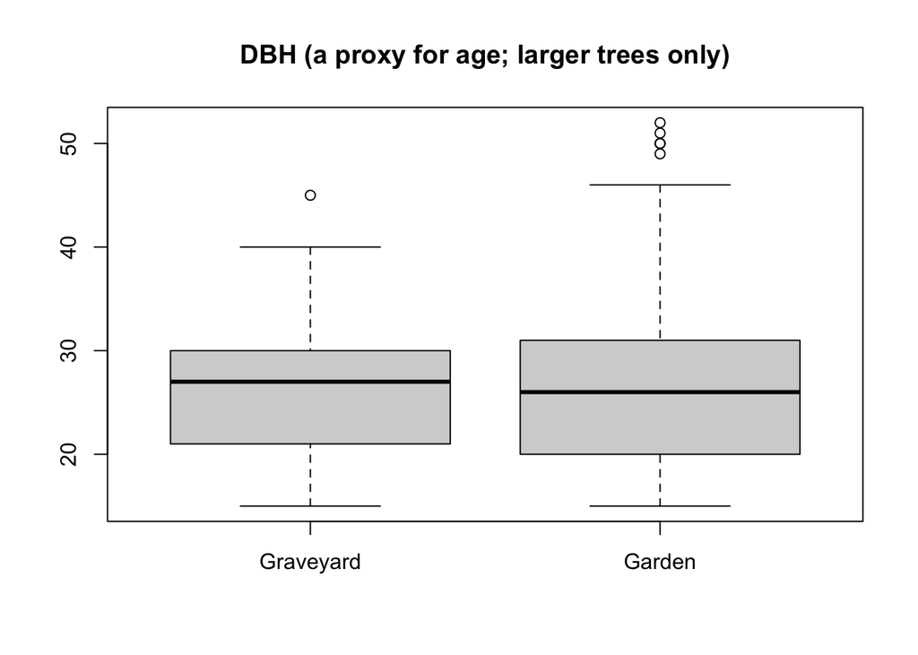

```r
boxplot(subset(tbl, loc=="graveyard" & dbh >= 15)$dbh,
        subset(tbl, loc=="garden" & dbh >= 15)$dbh,
        main="DBH (a proxy for age; larger trees only)",
        names=c("Graveyard", "Garden"))
```

With a cutoff of 15 inches dbh, we have comparable populations.

Now let’s compare their health.

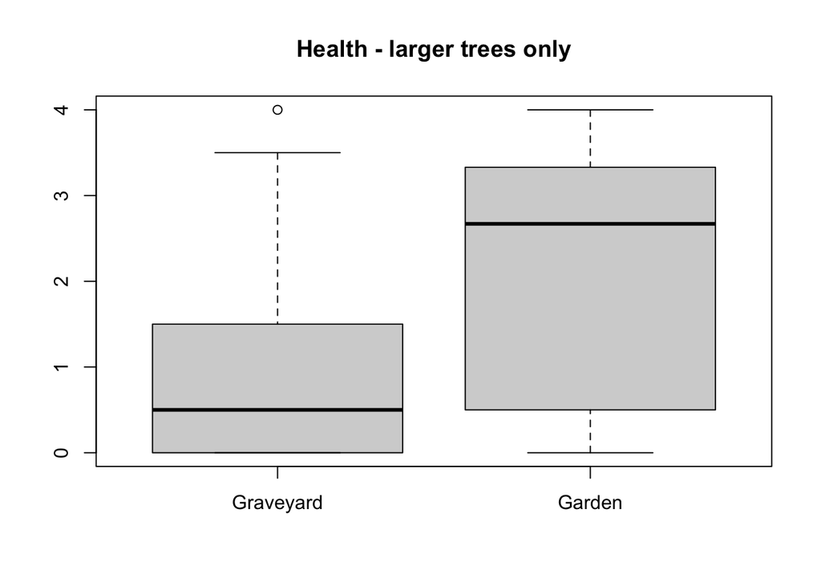

```r
boxplot(subset(tbl, loc=="graveyard" & dbh >= 15)$h,
        subset(tbl, loc=="garden" & dbh >= 15)$h,
        main="Health - larger trees only",
        names=c("Graveyard", "Garden"))
```

And obtain their t.test pvalue, which estimates the likelihood that the population difference could occur by chance.

```r
t.test(subset(tbl, loc=="graveyard" & dbh >= 15)$h,
       subset(tbl, loc=="garden" & dbh >= 15)$h)$p.value
```

```
## [1] 2.103177e-16
```

### Appendix C: Hemlock Health Assessment

We adapted aspects of the DMR (Dwarf Mistletoe Rating) system, originally suggested to us by Marianne Elliott in 2021. Our proxy for health was an informal estimate of the robustness and extent of needles on each third of the tree.

We learned early in the project that mature hemlocks, especially those which are in the canopy exposed to direct sun, self-prune their lower branches. In these cases we assigned the value **NA** to the lower thirds of the tree, so that the tree’s evolved response to canopy status is not counted as ill-health.

For each tree, we calculate a composite score, the average of the three section scores.

These ratings, and indeed the informal division of each tree’s trunk into thirds, are imprecise. Nonetheless, after the first few days in the field, all four of us easily reached consensus on each tree that we encountered, suggesting that these informal ratings can be easily reproduced by independent observers.

Understory trees usually fit the original model, in which bare, needle-sparese or recently fallen lower branches are a sign of ill-health.

Perhaps the best description of our method is that we assign grades of ill-health based on the evidence of failing needles, branchlets and branches where, according to healthy Western Hemlock needle and branch patterns, we expect them to flourish. In essence, our method was a consensus arising from negotiation of four ‘human [phenocams’](https://esajournals.onlinelibrary.wiley.com/doi/full/10.1002/ecs2.4487).

The DMR (Dwarf Mistletoe Rating) is described [here](https://forestpathology.org/parasitic-plants/dwarf-mistletoe/ecology/).

### Appendix D: Stastical Tests

The Student’s t-Test complements these boxplots, attaching a number value to the contrasts shown in the boxplots.

With respect to tree size (which roughly correlates with tree age) the two sites have the same distribution. A P-value of larger that 0.7 attests that these groups are highly similar by size.

```r
dbh.threshold <- 15
garden.bigTrees.dbh <- subset(tbl, loc=="garden" & dbh > dbh.threshold)$dbh
graveyard.bigTrees.dbh <- subset(tbl, loc=="graveyard" & dbh > dbh.threshold)$dbh

t.test(graveyard.bigTrees.dbh, garden.bigTrees.dbh)$p.value
```

```
## [1] 0.71514
```

### Appendix E: Kernel Density Calculations

For those interested in our method, and to provide a basis for possible future re-analysis of the data, here is the R code which

- partitions the trees into sick and healthy subsets
- calculates density plots for each subset
- saves selected density contours for import into the interactive map
- assigns each tree in the data set into one of three groups: garden, graveyard, none

The kernel density algorithm consists of these steps, and may be applied to all trees, or to a filtered subset:

1. Create a grid over the region
2. The grid may be coarse or fine; after experimentation, we settled on a cell count of 500
3. Every tree is assigned to a cell; 0, 1 or many trees are assigned to each cell
4. **kde2d** fits a smooth 2d surface over the grid cell counts
5. In the current version, we treat each tree equally, regardless of size and health status
6. Reasonable alternative approaches would adjust cell counts for the diameter, or cross-sectional area of each tree.

```r
library(MASS)
library(secr)
library(jsonlite)
f <- "https://pshannon.net/hemlockSurvey2024/tblFinal.csv"
tbl <- read.table(f, sep=",", header=TRUE, as.is=TRUE, nrow=-1, quote="")
tbl.h <- subset(tbl, h>=2) # | h <= 1)
seward.limits <- c(-122.25676, -122.248006, 47.548233, 47.562744)
cellCount <- 500
min.density <- 30000
f.healthy <- kde2d(tbl.h$lon, tbl.h$lat, n=cellCount, lims=seward.limits)
   # remove low density microsites
z <- f.healthy$z
range(z)
```

```
## [1] 2.052371e-117  1.829164e+05
```

```r
z[z <min.density] <- 0
f.healthy$z <- z
range(f.healthy$z)
```

```
## [1]      0.0 182916.4
```

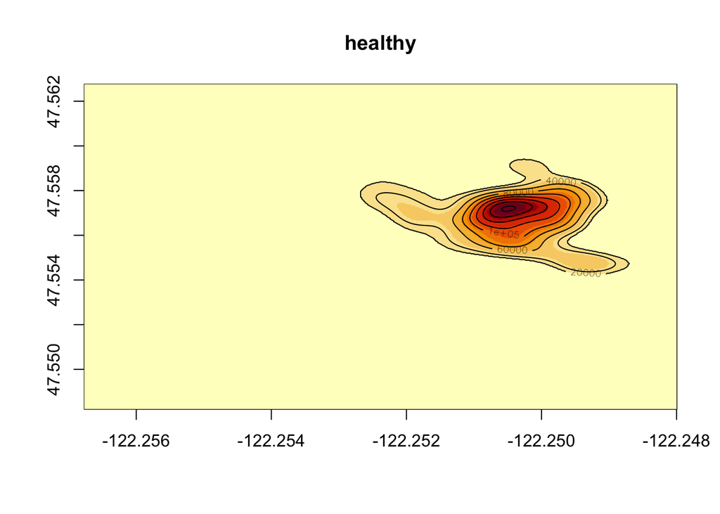

```r
image(f.healthy, main="healthy") # col=healthy.colors)
#dev.off()
contour(f.healthy, xlab = "healthy", add=TRUE)
```

```r
contours.healthy <- contourLines(f.healthy)
length(contours.healthy)  # 9
```

```
## [1] 9
```

```r
tbl.s <- subset(tbl, h <= 1)
f.sick <- kde2d(tbl.s$lon, tbl.s$lat, n=cellCount, lims=seward.limits)
z <- f.sick$z
range(z)
```

```
## [1] 8.095863e-40 1.147719e+05
```

```r
z[z <min.density] <- 0
f.sick$z <- z
range(f.sick$z)
```

```
## [1]      0.0 114771.9
```

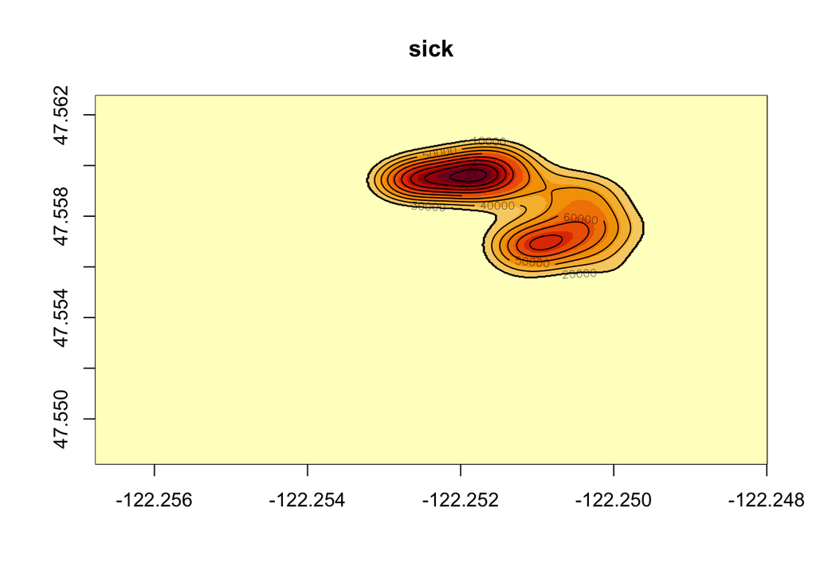

```r
image(f.sick, main="sick")
contour(f.sick, xlab = "sick", add=TRUE)
```

```r
contours.sick <- contourLines(f.sick)


#--------------------------------------------------------------------------------
# create a JSON data structure that looks like this:
#  [{lat:  47.55686380, lng: -122.25135673},
#   {lat:  47.55686981, lng: -122.25135821},
#   {lat:  47.55689889, lng: -122.25136372}]
contourAsJSON <- function(rec)
{
    stopifnot(names(rec) == c("level", "x", "y"))

    iter.span <- seq_len(length(rec$x))
    json <- toJSON(lapply(iter.span,
                          function(i)list(lat=rec$y[i], lng=rec$x[i])),
                   auto_unbox=TRUE,
                   na="string", digits=6)
    json

} # contourAsJSON
#--------------------------------------------------------------------------------
level.h <- 1
contours.healthy[[level.h]]$level
```

```
## [1] 20000
```

```r
jsonText = contourAsJSON(contours.healthy[[level.h]])
writeLines(jsonText, con="gardenBoundaries.json")

level.s <- 5
contours.sick[[level.s]]$level
```

```
## [1] 50000
```

```r
jsonText = contourAsJSON(contours.sick[[level.s]])
writeLines(jsonText, con="graveyardBoundaries.json")


tbl.garden <- fromJSON("gardenBoundaries.json")
dim(tbl.garden)  # 949 2
```

```
## [1] 963   2
```

```r
tbl.graveyard <- fromJSON("graveyardBoundaries.json")
dim(tbl.graveyard) # 395 2
```

```
## [1] 393   2
```

```r
colnames(tbl.garden) <- c("y", "x")
tbl.garden <- tbl.garden[, c("x", "y")]

colnames(tbl.graveyard) <- c("y", "x")
tbl.graveyard <- tbl.graveyard[, c("x", "y")]

in.garden <- which(pointsInPolygon(tbl[, c("lon", "lat")], tbl.garden))  # 448
in.graveyard <- which(pointsInPolygon(tbl[, c("lon", "lat")], tbl.graveyard))  # 144
length(intersect(in.garden, in.graveyard))  # 0
```

```
## [1] 0
```

```r
location <- rep("none", nrow(tbl))
location[in.garden] <- "garden"
location[in.graveyard] <- "graveyard"
table(location)
```

```
## location
##    garden graveyard      none
##       448       144       134
```

### Appendix F: Estimating the Age of Healthy Hemlocks in the Garden

In a 1983 journal article, Mark Harmon and Jerry Franklin offer a linear model relating Western Hemlock age in years to diameter in centimeters:

[Age Distribution of Western Hemlock and Its Relation to Roosevelt Elk Populations in the South Fork Hoh River Valley, Washington](https://andrewsforest.oregonstate.edu/sites/default/files/lter/pubs/pdf/pub214.pdf)

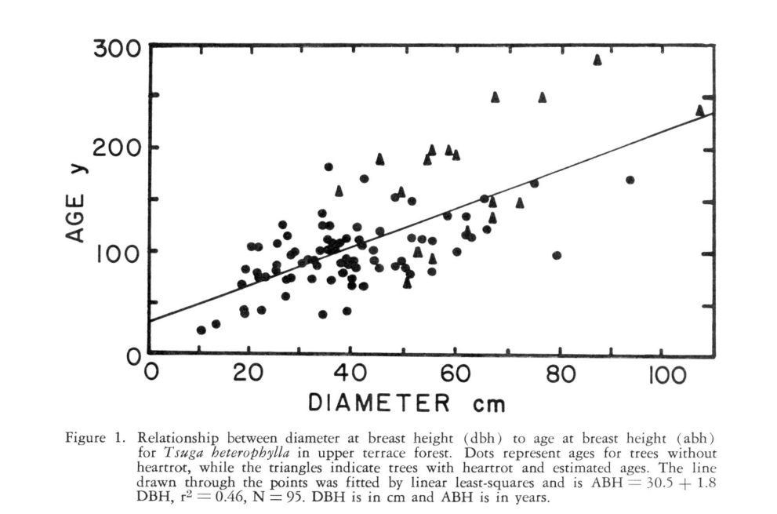

Their model comes from direct measurment, of diameter at breast height, and of tree age by counting rings after increment boring. If we apply their formula, while acknowledging that the Hoh River Valley receives four times as much rain as Seward Park, we find this profile of tree age.

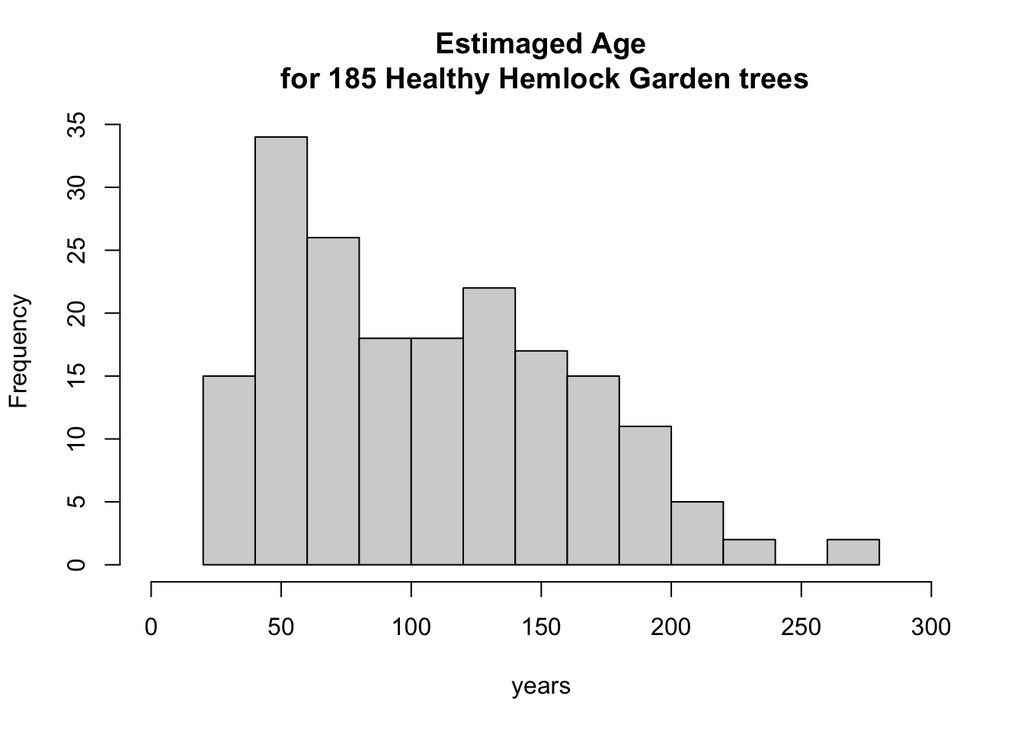

```r
dbh <- subset(tbl, loc=="garden" & h > 2.5)$dbh
dbh.cm <- 2.54 * dbh
age <- round(30.5 + (1.8 * dbh.cm))
hist(age, main="Estimaged Age\n for 185 Healthy Hemlock Garden trees", xlab="years",
     xlim=c(0,300))
```

The fire history of Seward’s forest may be relevant here. We believe that a stand replacement fire swept the peninsula about 1500. A more moderate fire burned through about 1720, survived by about 100 firs and a dozen cedars. Our oldest hemlocks may have seeded in within fify years of the more recent fire, as the surving douglas firs, and younger trees (maples? cedars?) formed a new canopy. [This fire history is drawn from diverse sources and is somewhat conjectural.]